# E-Commerce Sales Performance Dashboard Using R Shiny

## Author: Zach Schachter

### Introduction:

For any company, reporting is one of the most important tools for monitoring sales performance, financials and overall health of the business. Companies often compile reports on a monthly or quarterly basis and this can often be a tedious task. Metrics and other KPIs (Key Performance Indicators) are measured and displayed in concise and easy-to-read dashboards for executives, stakeholders and other employees.

The tools that companies use for reporting can often be expensive and complicated. The goal of this project was to create a simple, user-friendly and FREE app that can be used to display common e-commerce sales metrics in a visually appealing dashboard. Based on my experience working with e-commerce data, I wanted to design a dashboard that shows the most important and commonly used KPIs from companies I have worked with.

### Methods:

This dashboard was created using R Shiny in conjunction with ggplot2 and Bootstrap components.

The header and sidebar include links to the UF Dept of Biostatistics website and my Github page.

The icons used in the dashboard are from the Bootstrap Glyphicon library.

```r
suppressMessages(library(shiny))
suppressMessages(library(shinydashboard))
suppressMessages(library(ggplot2))
suppressMessages(library(dplyr))
suppressMessages(library(shinyjs))
suppressMessages(library(bslib))
suppressMessages(library(shinythemes))
suppressMessages(library(rmarkdown))
suppressMessages(library(httr))
suppressMessages(library(jsonlite))
suppressMessages(library(readxl))


#Dashboard header
header <- dashboardHeader(title = "E-commerce Dashboard")

#Sidebar content
sidebar <- dashboardSidebar(
  sidebarMenu(
    menuItem("Dashboard", tabName = "dashboard", icon = icon("dashboard")),
    menuItem("Learn More", icon = icon("education",lib='glyphicon'),
             href = "https://biostat.ufl.edu/"),
  menuItem("Github", icon = icon("hdd",lib='glyphicon'),
           href = "https://github.com/schachz/EcommerceShinyDashboard")
))
```

#### Fetching Data and Loading into R

```r
url<-('https://archive.ics.uci.edu/ml/machine-learning-databases/00352/Online%20Retail.xlsx')
GET(url, write_disk(ECOMdata <- tempfile(fileext = ".xlsx")))
```

```
## Response [https://archive.ics.uci.edu/ml/machine-learning-databases/00352/Online%20Retail.xlsx]
##   Date: 2022-12-06 04:13
##   Status: 200
##   Content-Type: application/x-httpd-php
##   Size: 23.7 MB
## <ON DISK>  C:\Users\schac\AppData\Local\Temp\RtmpK4nxB5\file434021654e6b.xlsx
```

```r
ECOMdata <- read_excel(ECOMdata)
```

#### Data Manipulation to calculate our KPIs

```r
totalprice <- ECOMdata$Quantity*ECOMdata$UnitPrice

total.revenue <- sum(totalprice)
totalorders <- length(unique(ECOMdata$InvoiceNo))


aov <- round(total.revenue/totalorders,digits = 2)
top.prod <- ECOMdata %>% group_by(Description) %>% summarise(value = sum(Quantity)) %>% filter(value==max(value))



unitsPerOrder <-  ECOMdata %>% group_by(InvoiceNo) %>% summarise(value = sum(Quantity))
avgUnitsPerOrder <- round(mean(unitsPerOrder$value),digits=2)
totalcustomers <- length(unique(ECOMdata$CustomerID))


top.products <- ECOMdata %>% group_by(StockCode) %>% summarise(value = sum(Quantity)) %>% arrange(desc(value))
top5prods <- top.products[1:5,]


topcountry <-  ECOMdata %>% group_by(Country) %>% summarise(value = sum(Quantity*UnitPrice)) %>% arrange(desc(value))

top5country <- topcountry[1:5,]
top5country$value <- round(top5country$value/1000,digits = 0)
```

The dashboard body consists of 3 fluid rows housing our KPI displays and bar chart plots.

#### Formatting the fluid rows:

```r
frow1 <- fluidRow(
  valueBoxOutput("value1")
  ,valueBoxOutput("value2")
  ,valueBoxOutput("value3")
)

frow2 <- fluidRow(

  box(
    title = "Top 5 Products by Units"
    ,status = "success"
    ,solidHeader = TRUE
    ,collapsible = TRUE
    ,plotOutput("top5products", height = "300px")
  )

  ,box(
    title = "Top 5 Countries by Revenue"
    ,status = "warning"
    ,solidHeader = TRUE
    ,collapsible = TRUE
    ,plotOutput("revenuebyCountry", height = "300px")
  )

)



frow3 <-  fluidRow(
  box(
    title = "Average Units per Orders", width = 4, solidHeader = TRUE, status = "info",
    avgUnitsPerOrder
  ),
  box(
    title = "Average Order Value", width = 4, solidHeader = TRUE,status = "warning",
    "$",aov
  ),
  box(
    title = "# of Customers", width = 4, solidHeader = TRUE, status = "success",
    totalcustomers
  )
)
```

The UI portion of the Shiny app combines our title, header, sidebar, body, and skin.

```r
# combining 3 fluid rows to make body of dashboard
body <- dashboardBody(frow1, frow2, frow3)


#Setting up User Interface
ui <- dashboardPage(title = 'Ecom Data Dashboard', header, sidebar, body, skin='black')
```

[figure not shown]

Header and Sidebar

The Server portion of the Shiny app contains our functions to generate our desired plots.

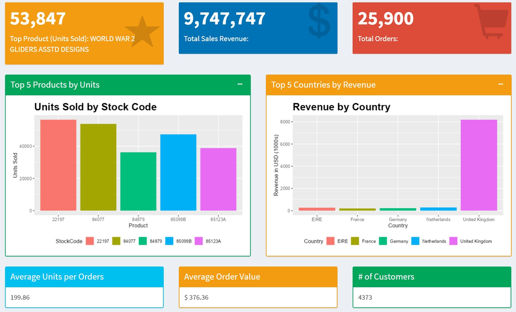

The results from our plots!

```r
# Establishing serve input functions
server <- function(input, output) {



#KPI Box Outputs
output$value1 <- renderValueBox({
    valueBox(
      formatC(top.prod$value, format="d", big.mark=',')
      ,paste('Top Product (Units Sold):',top.prod$Description)
      ,icon = icon("star",lib='glyphicon')
      ,color = "yellow")


  })



  output$value2 <- renderValueBox({

    valueBox(
      formatC(total.revenue, format="d", big.mark=',')
      ,'Total Sales Revenue:'
      ,icon = icon("usd",lib='glyphicon')
      ,color = "blue")

  })



  output$value3 <- renderValueBox({

    valueBox(
      formatC(totalorders, format="d", big.mark=',')
      ,paste('Total Orders:')
      ,icon = icon("shopping-cart",lib='glyphicon')
      ,color = "red")

  })

  #Creating output for the plots

  output$top5products <- renderPlot({
    ggplot(data = top5prods,
           aes(x=StockCode, y=value, fill=factor(StockCode))) +
      geom_bar(position = "dodge", stat = "identity") + ylab("Units Sold") +
      xlab("Product") + theme(legend.position="bottom"
                              ,plot.title = element_text(size=20, face="bold")) +
      ggtitle("Units Sold by Stock Code") + labs(fill = "StockCode")
  })


  output$revenuebyCountry <- renderPlot({
    ggplot(data = top5country,
           aes(x=Country, y=value, fill=factor(Country))) +
      geom_bar(position = "dodge", stat = "identity") + ylab("Revenue in USD (1000s)") +
      xlab("Country") + theme(legend.position="bottom"
                              ,plot.title = element_text(size=20, face="bold")) +
      ggtitle("Revenue by Country") + labs(fill = "Country")
  })


}
```

This function brings the UI and server portions together to get our Shiny app!

```r
# shinyApp(ui, server)
```

### Results:

The data used to test this app is actual data from a UK retailer containing sales from 01/12/2010 to 09/12/2011.

This dataset was pulled from the UCI Machine Learning Repository and made available by Dr Daqing Chen, Director of the Public Analytics group at London South Bank University.

```r
head(ECOMdata)
```

```
## # A tibble: 6 × 8
##   InvoiceNo StockC…¹ Descr…² Quant…³ InvoiceDate         UnitP…⁴ Custo…⁵ Country
##   <chr>     <chr>    <chr>     <dbl> <dttm>                <dbl>   <dbl> <chr>
## 1 536365    85123A   WHITE …       6 2010-12-01 08:26:00    2.55   17850 United…
## 2 536365    71053    WHITE …       6 2010-12-01 08:26:00    3.39   17850 United…
## 3 536365    84406B   CREAM …       8 2010-12-01 08:26:00    2.75   17850 United…
## 4 536365    84029G   KNITTE…       6 2010-12-01 08:26:00    3.39   17850 United…
## 5 536365    84029E   RED WO…       6 2010-12-01 08:26:00    3.39   17850 United…
## 6 536365    22752    SET 7 …       2 2010-12-01 08:26:00    7.65   17850 United…
## # … with abbreviated variable names ¹StockCode, ²Description, ³Quantity,
## #   ⁴UnitPrice, ⁵CustomerID
```